Nam Nguyen  
Nov 19, 2015  
For: Coursera Reproducible Research Peer Assessment 2

# Harmful Weather Events With Respect to Population Health and Economic Consequences in the United States Using the NOAA Storm Database"

## Synopsis

Using the NOAA Storm Database, the report explores the types of events in the Unites STates that are most harmful with respect to population health and with events have the greatest economic consequences.

Information about the NOAA Storm Database can be found here: https://d396qusza40orc.cloudfront.net/repdata%2Fpeer2_doc%2Fpd01016005curr.pdf

## Data Processes:

- Download the file from http://d396qusza40orc.cloudfront.net/repdata%2Fdata%2FStormData.csv.bz2
- load the file
- adding a year field to make analysis easier

```r
knitr::opts_chunk$set(cache=TRUE)
# download file
if (!"StormData.csv.bz2" %in% dir("./")) {
  download.file("http://d396qusza40orc.cloudfront.net/repdata%2Fdata%2FStormData.csv.bz2", destfile = "StormData.csv.bz2", mode="wb")
}

# load file
dataset <- read.csv("StormData.csv.bz2")

# add a year field
dataset$year <- as.numeric(format(as.Date(dataset$BGN_DATE, format = "%m/%d/%Y %H:%M:%S"), "%Y"))
```

## Data Summary

Most of the storm event data density is post mid 1990’s in the NOAA Storm Database as seen in the following histogram. So will look at events historically over all the data as well as just from 1995 and after:

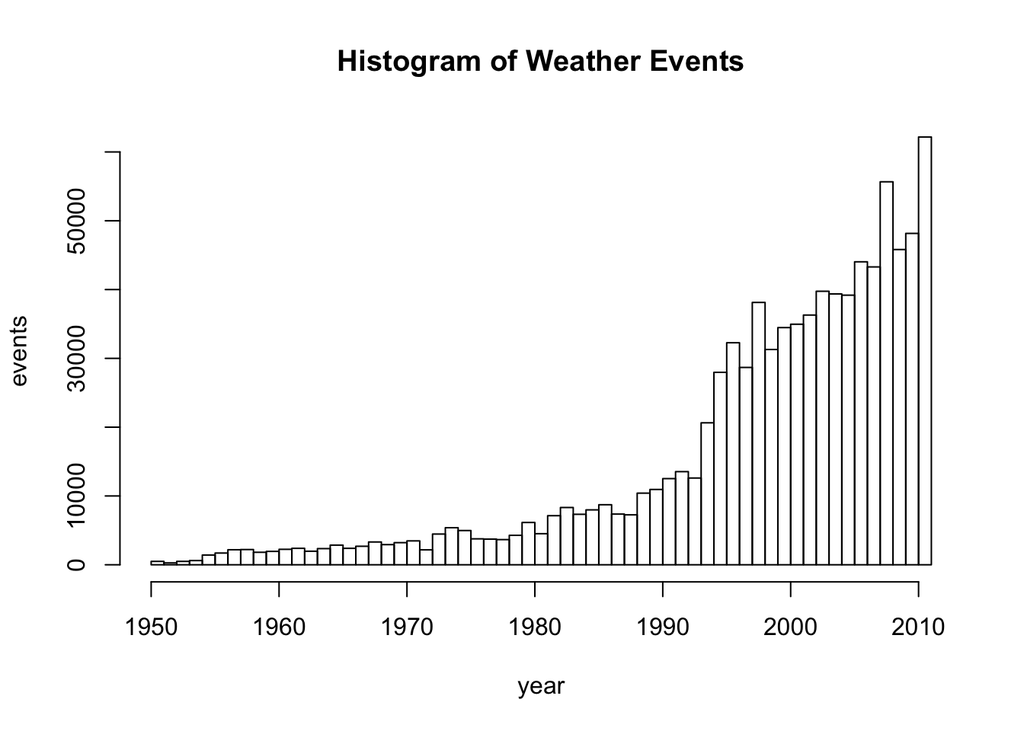

```r
hist(dataset$year, breaks = 50, xlab = "year", ylab = "events", main = "Histogram of Weather Events")
```

## Results

### Across the United States, which types of events are most harmful with respect to population health

#### Fatalities

First we’ll look at the events that have the top 10 number of fatalities overall

```r
#top 10 events by number of fatalities overall
fatalities <- aggregate(dataset$FATALITIES, by = list(toupper(dataset$EVTYPE)), FUN = "sum")
top10fatalities <- fatalities[order(fatalities$x, na.last = TRUE, decreasing = TRUE),]
names(top10fatalities) <- c("Events", "Fatalities")
head(top10fatalities,10)
```

```
##             Events Fatalities
## 758        TORNADO       5633
## 116 EXCESSIVE HEAT       1903
## 138    FLASH FLOOD        978
## 243           HEAT        937
## 418      LIGHTNING        816
## 779      TSTM WIND        504
## 154          FLOOD        470
## 524    RIP CURRENT        368
## 320      HIGH WIND        248
## 19       AVALANCHE        224
```

This shows overall that TORNADOS have killed the most people with EXCESSIVE HEAT and FLASH FLOOD trailing after.

Next we’ll look at the events that have the top ten number of fatalities since 1995

```r
#top 10 events by number of fatalities since 1995
dataset1995 <- dataset[dataset$year >= 1995,]
fatalities1995 <- aggregate(dataset1995$FATALITIES, by = list(toupper(dataset1995$EVTYPE)), FUN = "sum")
top10fatalities1995 <- fatalities1995[order(fatalities1995$x, na.last = TRUE, decreasing = TRUE),]
names(top10fatalities1995) <- c("Events", "Fatalities")
head(top10fatalities1995,10)
```

```
##             Events Fatalities
## 99  EXCESSIVE HEAT       1903
## 594        TORNADO       1545
## 120    FLASH FLOOD        934
## 200           HEAT        924
## 314      LIGHTNING        729
## 129          FLOOD        423
## 403    RIP CURRENT        360
## 251      HIGH WIND        241
## 610      TSTM WIND        241
## 16       AVALANCHE        223
```

This shows that recently EXCESSIVE HEAT is the top killer with TORNADOS closely behind.

#### Injuries

We can now do the same for Injuries.

First we’ll look at the events that have the top 10 number of injuries overall

```r
#top 10 events by number of injuries overall
injuries <- aggregate(dataset$INJURIES, by = list(toupper(dataset$EVTYPE)), FUN = "sum")
top10injuries <- injuries[order(injuries$x, na.last = TRUE, decreasing = TRUE),]
names(top10injuries) <- c("Events", "Injuries")
head(top10injuries,10)
```

```
##                Events Injuries
## 758           TORNADO    91346
## 779         TSTM WIND     6957
## 154             FLOOD     6789
## 116    EXCESSIVE HEAT     6525
## 418         LIGHTNING     5230
## 243              HEAT     2100
## 387         ICE STORM     1975
## 138       FLASH FLOOD     1777
## 685 THUNDERSTORM WIND     1488
## 212              HAIL     1361
```

This shows overall that TORNADOS have injured the most people with TSTM WIND and FLOOD trailing after.

```r
#top 10 events by number of injuries since 1995
injuries1995 <- aggregate(dataset1995$INJURIES, by = list(toupper(dataset1995$EVTYPE)), FUN = "sum")
top10injuries1995 <- injuries1995[order(injuries1995$x, na.last = TRUE, decreasing = TRUE),]
names(top10injuries1995) <- c("Events", "Injuries")
head(top10injuries1995,10)
```

```
##                Events Injuries
## 594           TORNADO    21765
## 129             FLOOD     6769
## 99     EXCESSIVE HEAT     6525
## 314         LIGHTNING     4631
## 610         TSTM WIND     3630
## 200              HEAT     2030
## 120       FLASH FLOOD     1734
## 536 THUNDERSTORM WIND     1426
## 707      WINTER STORM     1298
## 276 HURRICANE/TYPHOON     1275
```

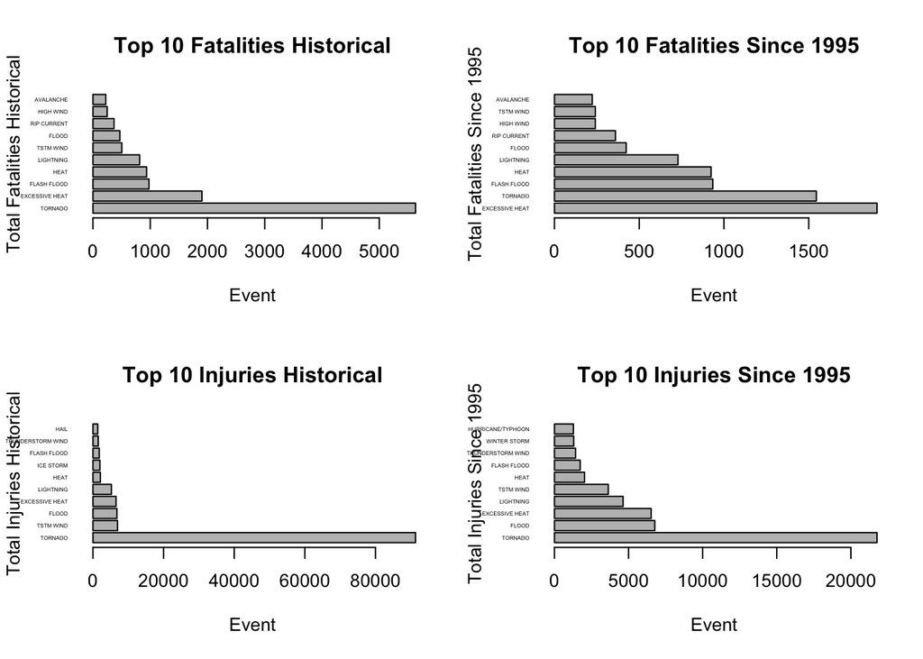

```r
par(mfrow=c(2,2))
barplot(head(top10fatalities$Fatalities,10), names = head(top10fatalities$Events,10) , xlab = "Event", ylab = "Total Fatalities Historical", main = "Top 10 Fatalities Historical" , cex.names = 0.3, horiz=TRUE, las=1)

barplot(head(top10fatalities1995$Fatalities,10), names = head(top10fatalities1995$Events,10) , xlab = "Event", ylab = "Total Fatalities Since 1995", main = "Top 10 Fatalities Since 1995" , cex.names = 0.3, horiz=TRUE, las=1)

barplot(head(top10injuries$Injuries,10), names = head(top10injuries$Events,10) , xlab = "Event", ylab = "Total Injuries Historical", main = "Top 10 Injuries Historical" , cex.names = 0.3, horiz=TRUE, las=1)

barplot(head(top10injuries1995$Injuries,10), names = head(top10injuries1995$Events,10) , xlab = "Event", ylab = "Total Injuries Since 1995", main = "Top 10 Injuries Since 1995" , cex.names = 0.3, horiz=TRUE, las=1)
```

## Across the United States, which types of events have the greatest economic consequences?

## Property Damage

Overall Property Damage

```r
property <- aggregate(dataset$PROPDMG, by = list(toupper(dataset$EVTYPE)), FUN = "sum")
names(property) <- c("EVENT","PROPERTY_DAMAGE")
top10property <- property[order(property$PROPERTY_DAMAGE, na.last = TRUE, decreasing = TRUE),]
head(top10property, 10)
```

```
##                  EVENT PROPERTY_DAMAGE
## 758            TORNADO       3212258.2
## 138        FLASH FLOOD       1420124.6
## 779          TSTM WIND       1335995.6
## 154              FLOOD        899938.5
## 685  THUNDERSTORM WIND        876844.2
## 212               HAIL        688693.4
## 418          LIGHTNING        603351.8
## 711 THUNDERSTORM WINDS        446293.2
## 320          HIGH WIND        324731.6
## 888       WINTER STORM        132720.6
```

we see that TORNADO followed by FLASH FLOOD, TSTM WIND, FLOOD, and THUNDERSTORM WIND compomise the top five.

```r
property1995 <- aggregate(dataset1995$PROPDMG, by = list(toupper(dataset1995$EVTYPE)), FUN = "sum")
names(property1995) <- c("EVENT","PROPERTY_DAMAGE")
top10property1995 <- property1995[order(property1995$PROPERTY_DAMAGE, na.last = TRUE, decreasing = TRUE),]
head(top10property1995, 10)
```

```
##                  EVENT PROPERTY_DAMAGE
## 610          TSTM WIND       1333373.6
## 120        FLASH FLOOD       1281800.5
## 594            TORNADO       1238637.6
## 536  THUNDERSTORM WIND        862964.7
## 129              FLOOD        838690.7
## 175               HAIL        597641.9
## 314          LIGHTNING        513832.1
## 251          HIGH WIND        315549.6
## 707       WINTER STORM        127119.6
## 561 THUNDERSTORM WINDS        107469.6
```

Since 1995 the top property damage events are similar in differing order

### CROP DAMAGE

Overall Crop Damage

```r
crop <- aggregate(dataset$CROPDMG, by = list(toupper(dataset$EVTYPE)), FUN = "sum")
names(crop) <- c("EVENT","CROP_DAMAGE")
top10crop <- crop[order(crop$CROP_DAMAGE, na.last = TRUE, decreasing = TRUE),]
head(top10crop, 10)
```

```
##                  EVENT CROP_DAMAGE
## 212               HAIL   579596.28
## 138        FLASH FLOOD   179200.46
## 154              FLOOD   168037.88
## 779          TSTM WIND   109202.60
## 758            TORNADO   100018.52
## 685  THUNDERSTORM WIND    66791.45
## 84             DROUGHT    33898.62
## 711 THUNDERSTORM WINDS    18684.93
## 320          HIGH WIND    17283.21
## 254         HEAVY RAIN    11122.80
```

we see that HAIL followed by FLASH FLOOD, FLOOD, TSTM WIND, TORNADO compomise the top five.

```r
crop1995 <- aggregate(dataset1995$CROPDMG, by = list(toupper(dataset1995$EVTYPE)), FUN = "sum")
names(crop1995) <- c("EVENT","CROP_DAMAGE")
top10crop1995 <- crop1995[order(crop1995$CROP_DAMAGE, na.last = TRUE, decreasing = TRUE),]
head(top10crop1995, 10)
```

```
##                 EVENT CROP_DAMAGE
## 175              HAIL   515218.08
## 120       FLASH FLOOD   166733.36
## 129             FLOOD   153654.83
## 610         TSTM WIND   109142.60
## 594           TORNADO    91551.02
## 536 THUNDERSTORM WIND    66702.00
## 73            DROUGHT    33348.62
## 251         HIGH WIND    17268.21
## 207        HEAVY RAIN    11117.80
## 155      FROST/FREEZE     7134.14
```

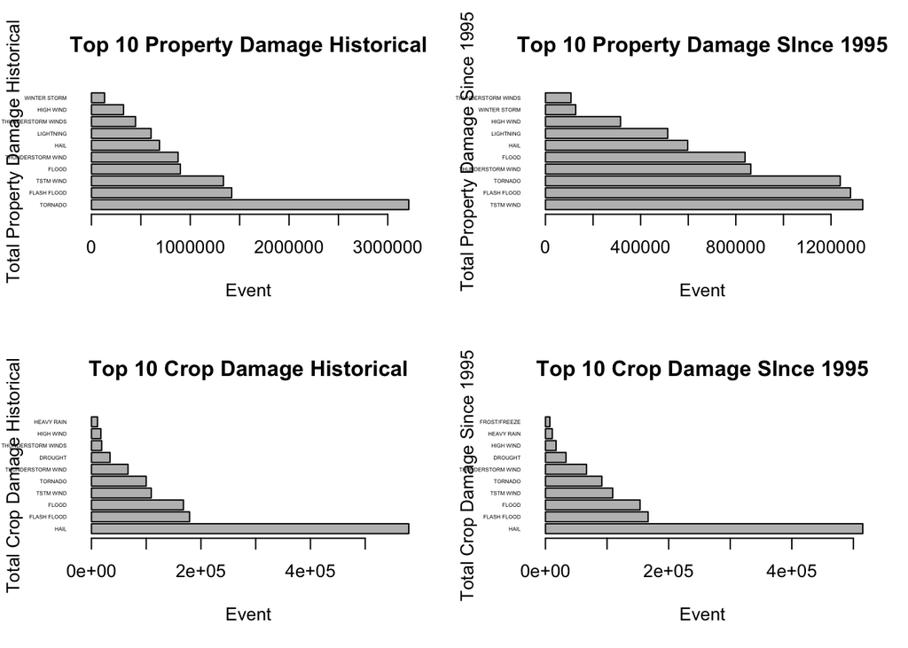

```r
par(mfrow=c(2,2))
barplot(head(top10property$PROPERTY_DAMAGE,10), names = head(top10property$EVENT,10) , xlab = "Event", ylab = "Total Property Damage Historical", main = "Top 10 Property Damage Historical" , cex.names = 0.3, horiz=TRUE, las=1)

barplot(head(top10property1995$PROPERTY_DAMAGE,10), names = head(top10property1995$EVENT,10) , xlab = "Event", ylab = "Total Property Damage Since 1995", main = "Top 10 Property Damage SInce 1995", cex.names = 0.3, horiz=TRUE, las=1)

barplot(head(top10crop$CROP_DAMAGE,10), names = head(top10crop$EVENT,10) , xlab = "Event", ylab = "Total Crop Damage Historical", main = "Top 10 Crop Damage Historical" , cex.names = 0.3, horiz=TRUE, las=1)

barplot(head(top10crop1995$CROP_DAMAGE,10), names = head(top10crop1995$EVENT,10) , xlab = "Event", ylab = "Total Crop Damage Since 1995", main = "Top 10 Crop Damage SInce 1995", cex.names = 0.3, horiz=TRUE, las=1)
```